# Phys434_thalyapaleologu_lab4

```python
%matplotlib inline
import numpy as np
import matplotlib
import matplotlib.pyplot as plt
import scipy
from scipy import stats
import h5py
from matplotlib import pylab
from pylab import *

#this sets the size of the plot to something useful
plt.rcParams["figure.figsize"] = (20,8)
```

```python
hf = h5py.File('gammaray_lab4.h5','r')
```

```python
hf.keys()
```

```
<KeysViewHDF5 ['data']>
```

```python
data = np.array(hf.get('data'))
```

```python
data[:,0]
```

```
array([9.40680016e+08, 3.15000000e+02, 4.50000000e+01, 1.00000000e+01])
```

```python
print(data.size)
```

```
103680004
```

```python
hf.close()
```

```python
len(data[0,:])
```

```
25920001
```

```python
time = data[0,:]
counts = data[3,:]
solarphase = data[1,:]
longitude = data[2,:]
```

# Lab 4

In this lab we will be exploring how to determine what type of distribution best fits our raw data

# Problem 1: Cosmic Background Radiation

In this problem we will be considering simulated data from a gamma-ray satellite orbiting Earth in low orbit. While it is looking for Gamma-Ray Bursts, a majority of the data it collects are cosmic rays--that is, the cosmic rays appear as our background.

The satellite takes a reading every 100 milliseconds and its orbit is 90 minutes long. Hence we have 54,000 measurments per orbit (of the satellite around Earth).

Our data consists of 25,920,001 different readings, hence we have data collected over 480 orbits of the satellite around Earth.

Our data consists of 4 columns, listed in order: Time (GPS sec), Solar Phase (deg), Earth Longitude (deg), Particle Counts.

We want to explore what our background of cosmic rays looks like.

# 1.1 Varies with Longitude

Our first step is to make a plot of the total number of counts as a function of time. When we try to plot all of the data at once it is hard to see any features since there is so much data.

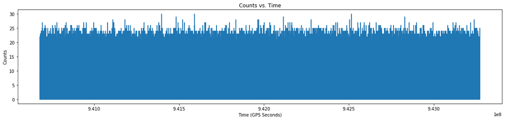

```python
figure(figsize = (20,4))
plt.title('Counts vs. Time')
plt.xlabel('Time (GPS Seconds)')
plt.ylabel('Counts')
plt.plot(time,counts)
plt.show()
```

So we must decide on a suitable range to look at so that we might see any features that arise in our background.

Since we know our satellite is physically orbiting around Earth, we expect to see a periodicity on the scale of 90 minutes. Hence we need to make sure we plot data that includes at least one full orbit's worth of measurements. We would like to see if there are 'slower' features than the periodicity caused by the 90-minute orbit, so we should actually plot multiple orbits' worth of data.

Recall that 1 orbit = 54,000 measurements. Below we plot data collected over five orbits

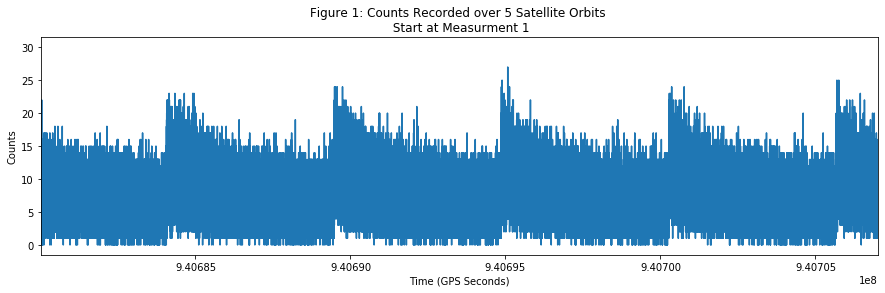

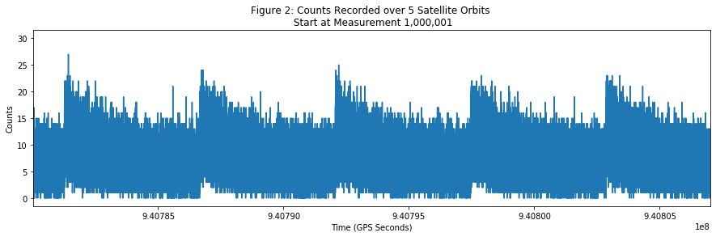

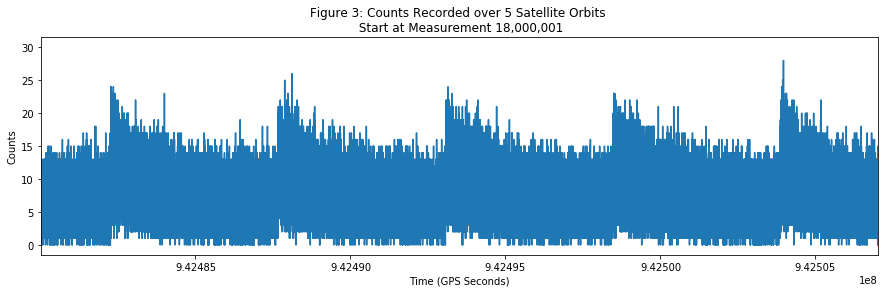

```python
figure(figsize = (15,4))
plt.title('Figure 1: Counts Recorded over 5 Satellite Orbits \n Start at Measurment 1')
plt.xlabel('Time (GPS Seconds)')
plt.ylabel('Counts')
plt.xlim([time[0],time[0]+27000]) #5 orbits (5*5400 sec/orbit = 27000 sec)
plt.plot(time,counts)

figure(figsize = (15,4))
plt.title('Figure 2: Counts Recorded over 5 Satellite Orbits \n Start at Measurement 1,000,001')
plt.xlabel('Time (GPS Seconds)')
plt.ylabel('Counts')
plt.xlim([time[1000000],time[1000000]+27000]) #5 orbits (5*5400 sec/orbit = 27000 sec)
plt.plot(time,counts)

figure(figsize = (15,4))
plt.title('Figure 3: Counts Recorded over 5 Satellite Orbits \n Start at Measurement 18,000,001')
plt.xlabel('Time (GPS Seconds)')
plt.ylabel('Counts')
plt.xlim([time[18000000],time[18000000]+27000]) #5 orbits (5*5400 sec/orbit = 27000 sec)
plt.plot(time,counts)

plt.show()
```

We see that there is in fact a periodicity to our background data as we include multiple orbits. In fact, the period appears to be around 5,400 seconds = 90 minutes. Let's make a plot of how the longitude varies with time and overlay this onto our data so we can see if there is indeed a correlation:

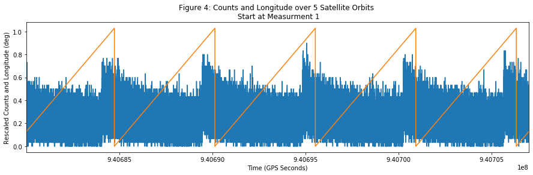

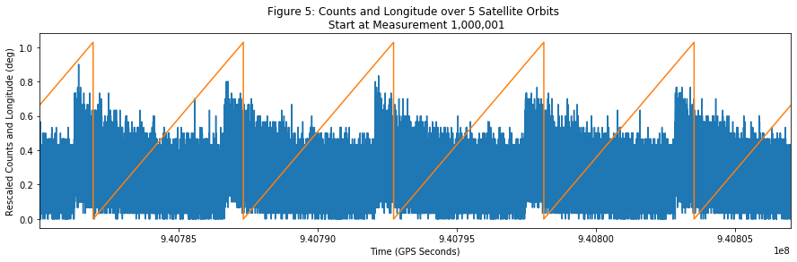

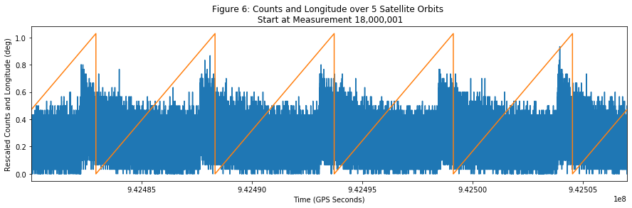

```python
figure(figsize = (15,4))
plt.title('Figure 4: Counts and Longitude over 5 Satellite Orbits \n Start at Measurment 1')
plt.xlabel('Time (GPS Seconds)')
plt.ylabel('Rescaled Counts and Longitude (deg)')
plt.xlim([time[0],time[0]+27000]) #5 orbits (5*5400 sec/orbit = 27000 sec)
plt.plot(time,counts/30) #we rescale for easier comparison
plt.plot(time,longitude/350) #we rescale for easier comparison

figure(figsize = (15,4))
plt.title('Figure 5: Counts and Longitude over 5 Satellite Orbits \n Start at Measurement 1,000,001')
plt.xlabel('Time (GPS Seconds)')
plt.ylabel('Rescaled Counts and Longitude (deg)')
plt.xlim([time[1000000],time[1000000]+27000]) #5 orbits (5*5400 sec/orbit = 27000 sec)
plt.plot(time,counts/30)
plt.plot(time,longitude/350)

figure(figsize = (15,4))
plt.title('Figure 6: Counts and Longitude over 5 Satellite Orbits \n Start at Measurement 18,000,001')
plt.xlabel('Time (GPS Seconds)')
plt.ylabel('Rescaled Counts and Longitude (deg)')
plt.xlim([time[18000000],time[18000000]+27000]) #5 orbits (5*5400 sec/orbit = 27000 sec)
plt.plot(time,counts/30)
plt.plot(time,longitude/350)

plt.show()
```

Note that for easy comparison we have rescaled the longitude by 1/350, and the counts by 1/30. we see that the periodicity of our count data seems to be well-correlated with the longitudinal position of the satellite. That is, the background is not constant simply because the satellite is orbiting the earth and hence looking at different portions of space as it orbits.

We still cannot say anything about signal contamination; since our background varies with longitude (or, equivalently, with time), we must first determine what our background looks like as a function of where the satellite is in space so that we can then determine from a localized distribution whether or not a measurement is likely to be a signal.

Before we delve into using longitudnal data to help us look at our background, let's take a quick look at how the background varies with solar phase:

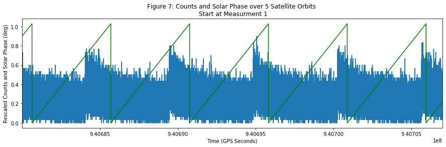

[figure not shown]

[figure not shown]

```python
figure(figsize = (15,4))
plt.title('Figure 7: Counts and Solar Phase over 5 Satellite Orbits \n Start at Measurment 1')
plt.xlabel('Time (GPS Seconds)')
plt.ylabel('Rescaled Counts and Solar Phase (deg)')
plt.xlim([time[0],time[0]+27000]) #5 orbits (5*5400 sec/orbit = 27000 sec)
plt.plot(time,counts/30) #we rescale for easier comparison
plt.plot(time,solarphase/350,'g') #we rescale for easier comparison

figure(figsize = (15,4))
plt.title('Figure 8: Counts and Solar Phase over 5 Satellite Orbits \n Start at Measurment 1')
plt.xlabel('Time (GPS Seconds)')
plt.ylabel('Rescaled Counts and Solar Phase (deg)')
plt.xlim([time[1000000],time[1000000]+27000]) #5 orbits (5*5400 sec/orbit = 27000 sec)
plt.plot(time,counts/30) #we rescale for easier comparison
plt.plot(time,solarphase/350,'g') #we rescale for easier comparison

figure(figsize = (15,4))
plt.title('Figure 9: Counts and Solar Phase over 5 Satellite Orbits \n Start at Measurment 1')
plt.xlabel('Time (GPS Seconds)')
plt.ylabel('Rescaled Counts and Solar Phase (deg)')
plt.xlim([time[18000000],time[18000000]+27000]) #5 orbits (5*5400 sec/orbit = 27000 sec)
plt.plot(time,counts/30) #we rescale for easier comparison
plt.plot(time,solarphase/350,'g') #we rescale for easier comparison

plt.show()
```

We see that there is not a strong correlation between solar phase and counts, as the periodicity of the two functions are different.

## 1.2 How Background Varies Longitudinally

Since we can look at our data as **counting rays within a longitudinal interval** we expect our distribution for the average number of counts in a given region of space to be **Poisson Distributed**. Below we plot the histograms for the average counts in different longitudinal intervals: 1 orbit, 1/2 orbit, 1/4 orbit, 1/8 orbit, and 1/16 orbit.

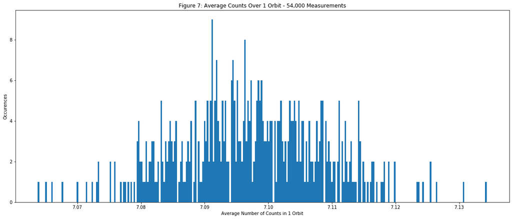

```python
averagearray = np.array([])
averageover = 54000 #average over 1 orbit = 54000 measurements

j = 0
while j < 480:
    sumvar = 0
    for i in range(j*54000,(j+1)*54000):
        sumvar = sumvar + counts[i]

    average1orbit = sumvar/54000
    averagearray = np.append(averagearray,[average1orbit])
    j = j+1

figure()
plt.title('Figure 7: Average Counts Over 1 Orbit - 54,000 Measurements')
plt.xlabel('Average Number of Counts in 1 Orbit')
plt.ylabel('Occurences')
plt.hist(averagearray,300)
plt.show()
```

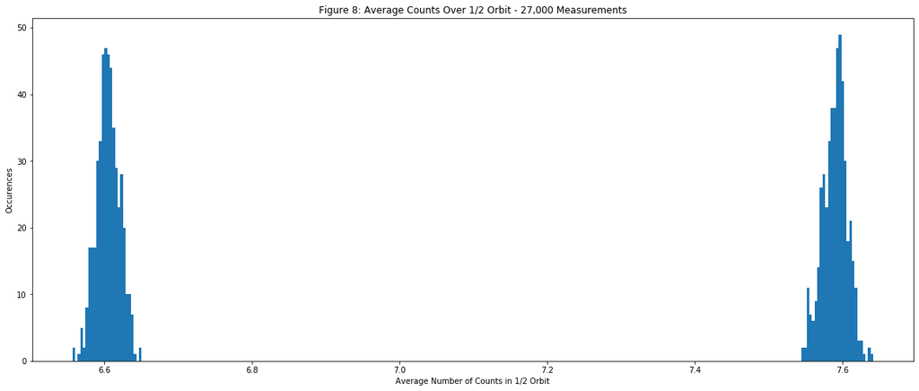

```python
averagearray = np.array([])
averageover = 27000 #average over 1/2 orbit = 27000 measurements

j = 0
while j < 480*2:
    sumvar = 0
    for i in range(j*27000,(j+1)*27000):
        sumvar = sumvar + counts[i]

    average1orbit = sumvar/27000
    averagearray = np.append(averagearray,[average1orbit])
    j = j+1


figure()
plt.title('Figure 8: Average Counts Over 1/2 Orbit - 27,000 Measurements')
plt.xlabel('Average Number of Counts in 1/2 Orbit')
plt.ylabel('Occurences')
plt.hist(averagearray,300)
plt.show()
```

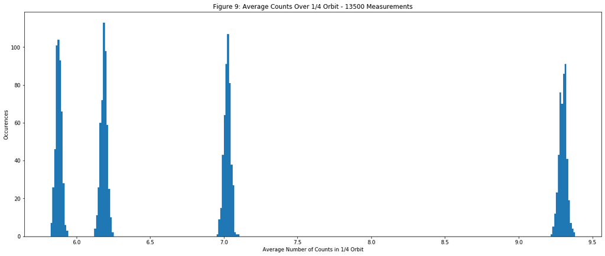

```python
averagearray = np.array([])
averageover = 13500 #average over 1/4 orbit = 13500 measurements

j = 0
while j < 480*4:
    sumvar = 0
    for i in range(j*13500,(j+1)*13500):
        sumvar = sumvar + counts[i]

    average1orbit = sumvar/13500
    averagearray = np.append(averagearray,[average1orbit])
    j = j+1


figure()
plt.title('Figure 9: Average Counts Over 1/4 Orbit - 13500 Measurements')
plt.xlabel('Average Number of Counts in 1/4 Orbit')
plt.ylabel('Occurences')
plt.hist(averagearray,300)
plt.show()
```

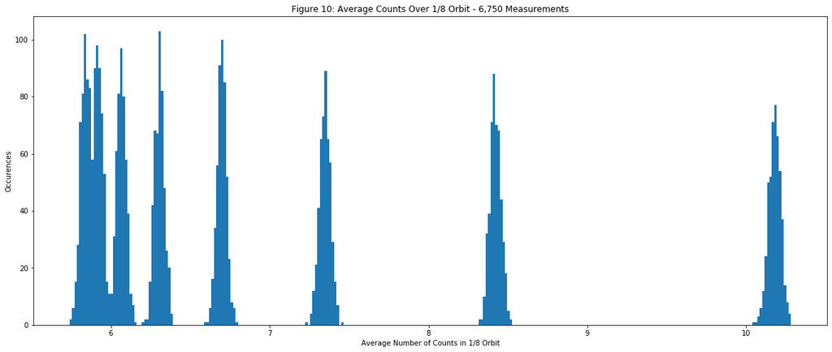

```python
averagearray = np.array([])
averageover = 6750 #average over 1/8 orbit = 6750 measurements

j = 0
while j < 480*8:
    sumvar = 0
    for i in range(j*6750,(j+1)*6750):
        sumvar = sumvar + counts[i]

    average1orbit = sumvar/6750
    averagearray = np.append(averagearray,[average1orbit])
    j = j+1


figure()
plt.title('Figure 10: Average Counts Over 1/8 Orbit - 6,750 Measurements')
plt.xlabel('Average Number of Counts in 1/8 Orbit')
plt.ylabel('Occurences')
plt.hist(averagearray,300)
plt.show()
```

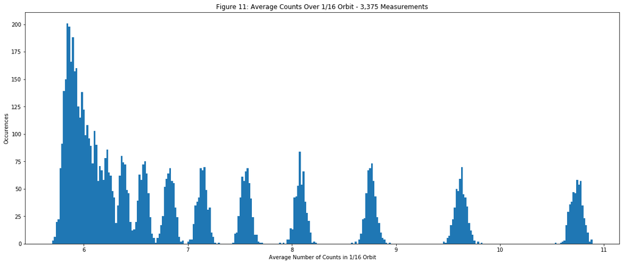

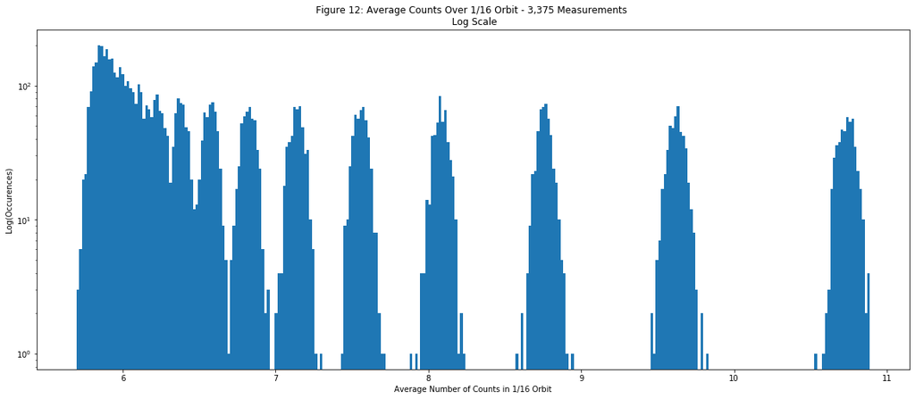

```python
averagearray = np.array([])
averageover = 3375 #average over 1/16 orbit = 3375 measurements

j = 0
while j < 480*16:
    sumvar = 0
    for i in range(j*3375,(j+1)*3375):
        sumvar = sumvar + counts[i]

    average1orbit = sumvar/3375
    averagearray = np.append(averagearray,[average1orbit])
    j = j+1


figure()
plt.title('Figure 11: Average Counts Over 1/16 Orbit - 3,375 Measurements')
plt.xlabel('Average Number of Counts in 1/16 Orbit')
plt.ylabel('Occurences')
plt.hist(averagearray,300)


figure()
plt.title('Figure 12: Average Counts Over 1/16 Orbit - 3,375 Measurements \n Log Scale')
plt.xlabel('Average Number of Counts in 1/16 Orbit')
plt.ylabel('Log(Occurences)')
plt.hist(averagearray,300)
plt.yscale('log')

plt.show()
```

We see that as we average over smaller spatial intervals we get more and more distinct peaks that appear to be poisson distributed. In Figure 12 We have plotted the log scale of Figure 11 to see that each distribution indeed resembles a discrete version of a negative quadratic which is indicative of Poisson Distributions.

Hence, we conclude that our background is a **Poisson Distribution whose average varies with longitude**. That is:

$$ f(l) = \frac{\mu(l)}{k!} e^{-\mu(l)},$$

where the average $\mu(l)$ is a function of longitude, $l$, (or alternatively can be transformed to a function of time). **note that the above plot does not plot counts as a function of longitude; rather distinct peaks appear because each longitudinal segment will produce a new poisson distribution. We check our hypothesis in the next two figures.**

Below we calculate the histogram over each 1/16 orbit and then calculate the mean of the histogram to find where our Poisson distributions are centered. To further convince ourselves that a Poisson is a good *local* model of our data, we also display an overlayed Poisson distribution over what we expect the first two distributions in Figure 11 to be.

```python
def poisson16orbit(interval):
    min = interval*3375
    max = min + 3375

    batch = np.array([])
    while max <= 25920000:
        sumvar = 0
        for i in range(min,max):
            sumvar = sumvar + counts[i]


        batch = np.append(batch,[sumvar])
        min = min+54000
        max = max+54000 #move to next orbit

    return(batch)
```

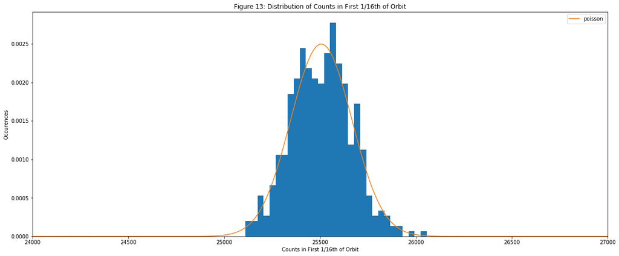

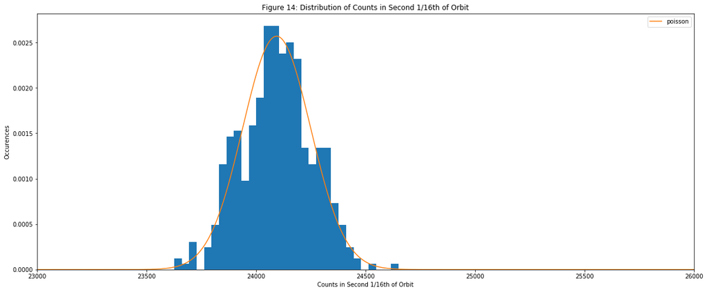

```python
#here we display our first two poisson distributions

batch1 = poisson16orbit(0)

fig,ax = plt.subplots(1,1)
ax.hist(batch1,30,density = True)
plt.xlim([24000,27000])
x = np.arange(0,50000,1)
ax.plot(stats.poisson.pmf(x, np.mean(batch1)),label = 'poisson')
leg = ax.legend()
plt.title('Figure 13: Distribution of Counts in First 1/16th of Orbit')
plt.xlabel('Counts in First 1/16th of Orbit')
plt.ylabel('Occurences')
plt.show()

batch2 = poisson16orbit(1)

fig,ax = plt.subplots(1,1)
ax.hist(batch2,30,density = True)
plt.xlim([23000,26000])
x = np.arange(0,50000,1)
ax.plot(stats.poisson.pmf(x, np.mean(batch2)),label = 'poisson')
leg = ax.legend()
plt.title('Figure 14: Distribution of Counts in Second 1/16th of Orbit')
plt.xlabel('Counts in Second 1/16th of Orbit')
plt.ylabel('Occurences')
plt.show()
```

```python
#here we calculate the average of all 16 of our distributions in Figure 11 (and Figure 12)
averages = np.array([])
for j in range(16):
    temp = poisson16orbit(j)
    average = np.mean(temp)
    averages = np.append(averages,average)

for i in range(16):
    print('Poisson Distribution of longitudinal segment', i+1 , 'centered at: ', averages[i], 'counts')
```

```
Poisson Distribution of longitudinal segment 1 centered at:  25506.8 counts
Poisson Distribution of longitudinal segment 2 centered at:  24094.475 counts
Poisson Distribution of longitudinal segment 3 centered at:  23028.3125 counts
Poisson Distribution of longitudinal segment 4 centered at:  22189.11875 counts
Poisson Distribution of longitudinal segment 5 centered at:  21540.227083333335 counts
Poisson Distribution of longitudinal segment 6 centered at:  21023.735416666666 counts
Poisson Distribution of longitudinal segment 7 centered at:  20627.577083333334 counts
Poisson Distribution of longitudinal segment 8 centered at:  20324.735416666666 counts
Poisson Distribution of longitudinal segment 9 centered at:  20073.966666666667 counts
Poisson Distribution of longitudinal segment 10 centered at:  19899.65625 counts
Poisson Distribution of longitudinal segment 11 centered at:  19757.335416666665 counts
Poisson Distribution of longitudinal segment 12 centered at:  19634.033333333333 counts
Poisson Distribution of longitudinal segment 13 centered at:  36235.06041666667 counts
Poisson Distribution of longitudinal segment 14 centered at:  32477.3 counts
Poisson Distribution of longitudinal segment 15 centered at:  29565.470833333333 counts
Poisson Distribution of longitudinal segment 16 centered at:  27276.66875 counts
```

We now wish to plot the above averages as a function of longitude. Since we are looking at orbital segments, we will plot the averages as a function of *the number of segments (1/16 orbit) we are away from the start:

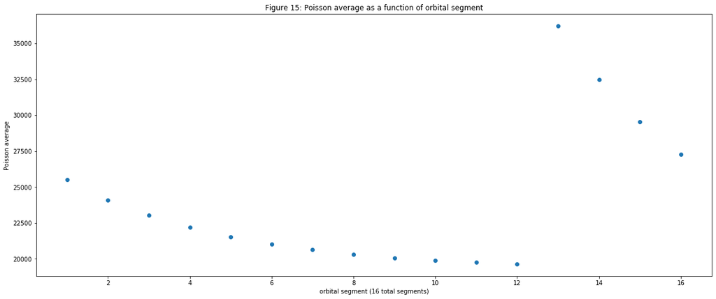

```python
#our longitudinal variable is an integer, represents how many 1/16th orbits we are from the 'start'
l = np.arange(1,17)
plt.scatter(l,averages)
plt.title('Figure 15: Poisson average as a function of orbital segment')
plt.xlabel('orbital segment (16 total segments)')
plt.ylabel('Poisson average')
plt.show()
```

Observe that there is a 'jump' in our function. This is because we chose to define our 'start' of the orbit at an inconveniant location. None of the physics changes if we simply redefine our 'start' to be the 13th segment. We plot the resulting graph below:

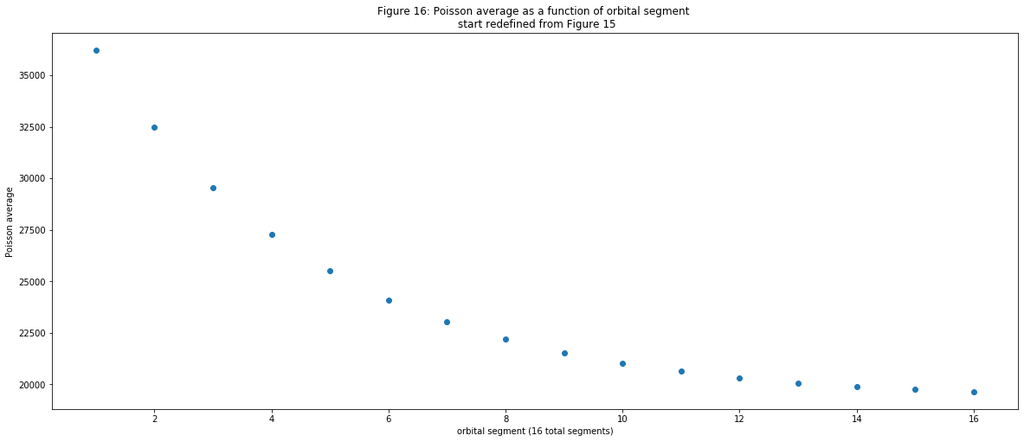

```python
lastfour = averages[[12,13,14,15]]
editedaverages = np.append(lastfour,averages)
editedaverages = editedaverages[0:16]
plt.scatter(l,editedaverages)
plt.title('Figure 16: Poisson average as a function of orbital segment \n start redefined from Figure 15')
plt.xlabel('orbital segment (16 total segments)')
plt.ylabel('Poisson average')
plt.show()
```

It is now easier to see that our Poisson average varies smoothly as we increase longitude. Letting $x$ be such that $16x = $ *distance traveled from start in longitudinal units*, we find that a good quadratic fit to the above data is $f(x) = 0.0317x^2 -0.8207x +11.1$, **where we rescaled our y-axis by 1/3375 so that our Poisson distributions correspond to the average counts in each segment**.

## 1.3 Sensitivity Threshold

Since our Poisson average decreases from our selected 'start point' as the satellite orbits Earth, **our sensitivity threshold also decreases* since we define our signal-like measurements to be large counts.

# Problem 2

In this problem we will be looking at 10 images of the same portion of the sky, and we will be looking for transient objects (objects that appear in only one image, a supernova for example). Below we load up our data and display an example of an image taken.

```python
hf1 = h5py.File('images.h5', 'r')
```

```python
hf1.keys()
```

```
<KeysViewHDF5 ['image1', 'imagestack']>
```

```python
imdata = np.array(hf1.get('image1'))
stackdata = np.array(hf1.get('imagestack'))
```

```python
print(stackdata.shape)
```

```
(200, 200, 10)
```

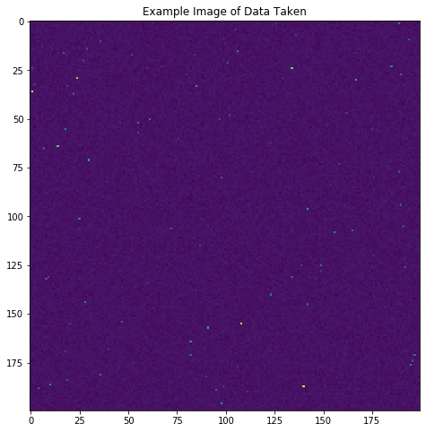

```python
figure()
plt.imshow(imdata)
plt.title('Example Image of Data Taken')
plt.show()
```

## 2.1 Determining Background

Before we can look for a signal, we need to decide what our background looks like. Since our signal is *transient objects* -- objects that appear in only one image -- we may virtually eliminate these signals by *averaging* all of our images together. Objects that are persistent--appear in nearly all 10 images--will have an average brightness that is close to the brightness in each individual picture.

However, objects that appear only once will have an average brightness that is 1/10th of the brightness that appears in that one image.

Hence if we make a histogram of the average brightnesses in the averaged picture, we will essentially be ignoring the transient signal; we can then histogram each picture individually to identify where a possible signal might be, and use our averaged background to determine the significance.

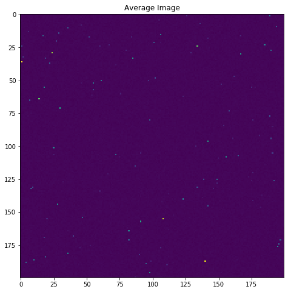

```python
#below we calculate the average image and display it
stackedimage = stackdata[:,:,0]
for i in range(1,10):
    stackedimage = stackedimage + stackdata[:,:,i]

stackedimage = stackedimage/10

plt.imshow(stackedimage)
plt.title('Average Image')
plt.show()
```

To determine the background we take our averaged image and histogram the brightness:

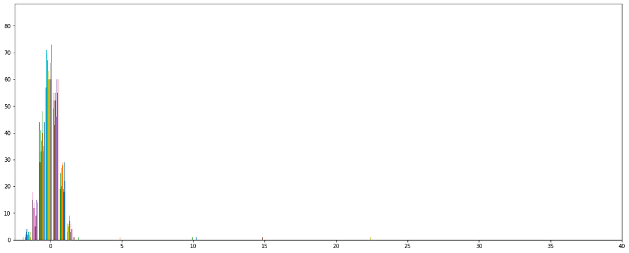

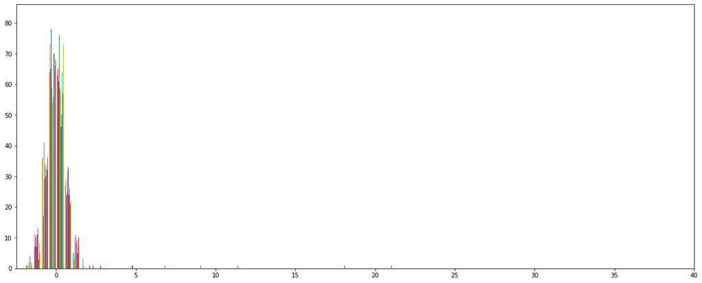

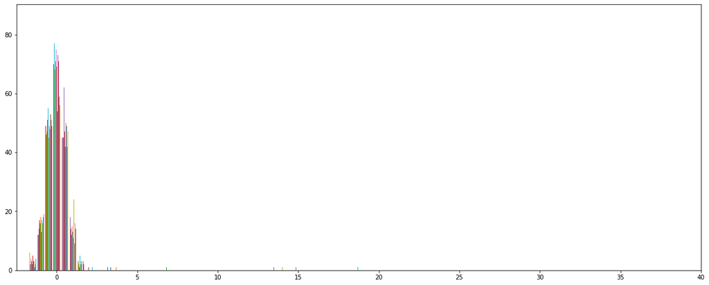

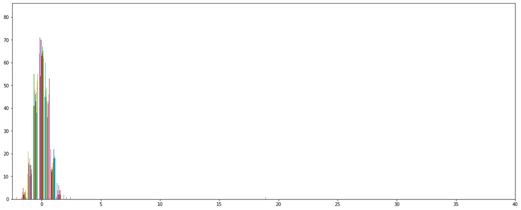

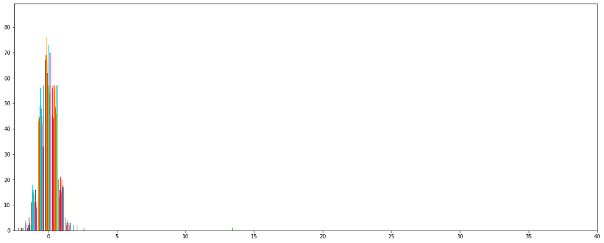

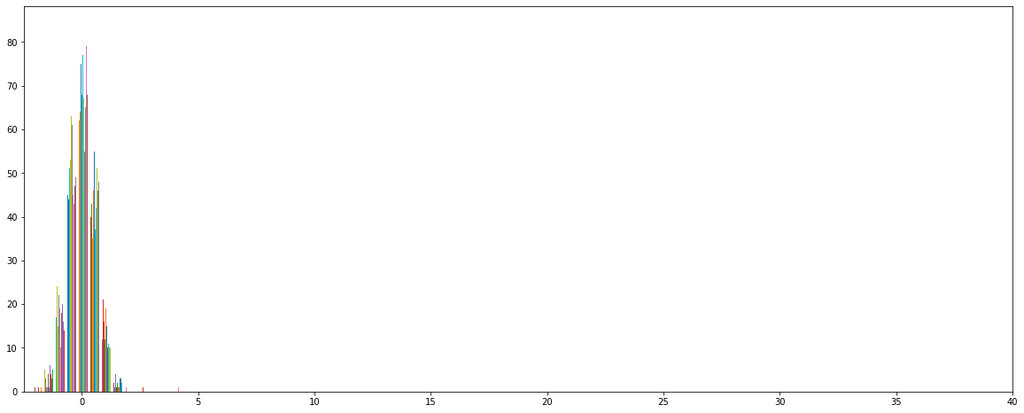

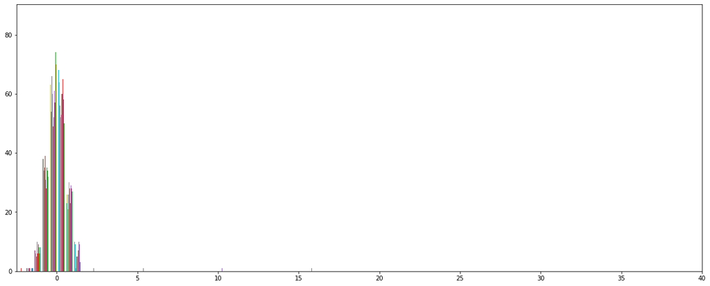

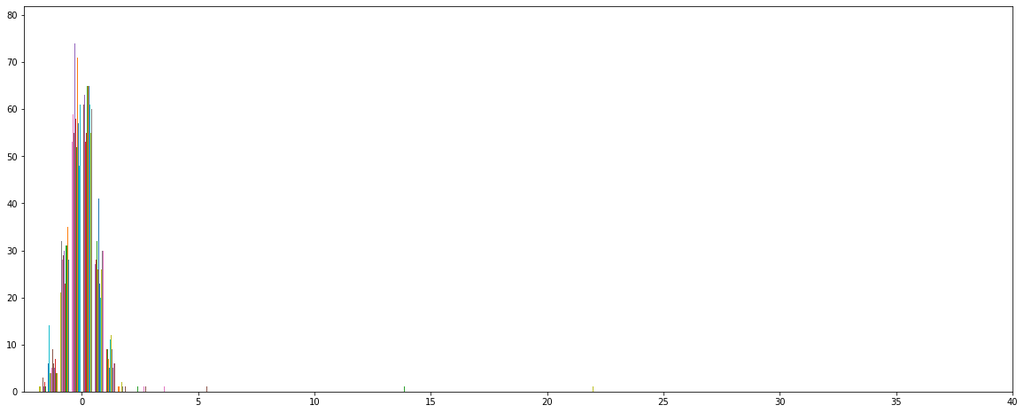

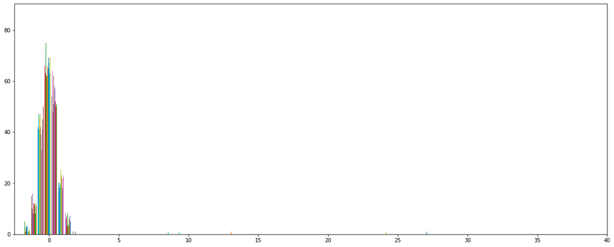

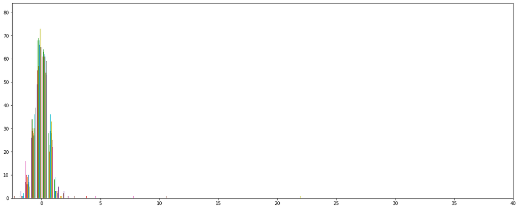

```python
for i in range(10):
    figure()
    plt.xlim([-2.5,40])
    plt.hist(stackdata[:,:,i],bins = 100)


plt.show()
```

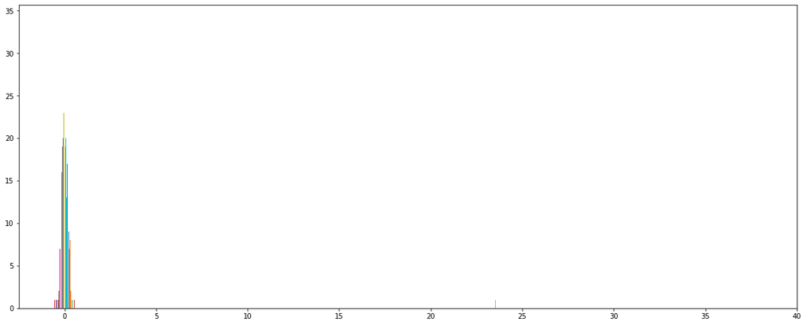

```python
plt.hist(stackedimage,bins = 1000)
plt.xlim([-2.5,40])
plt.show()
```